# Data 624 Homework 1

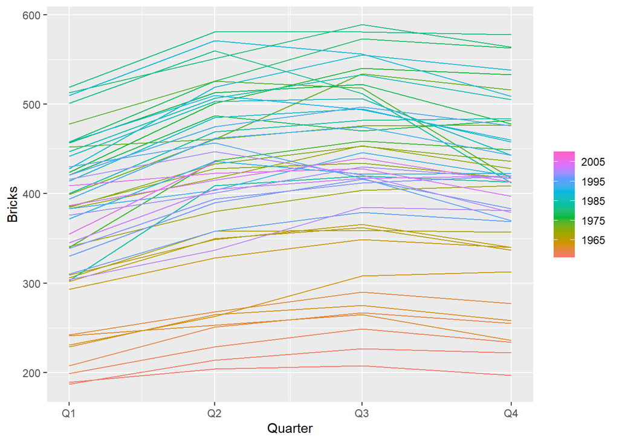

```r
gg_season(aus_production, y = Bricks)
```

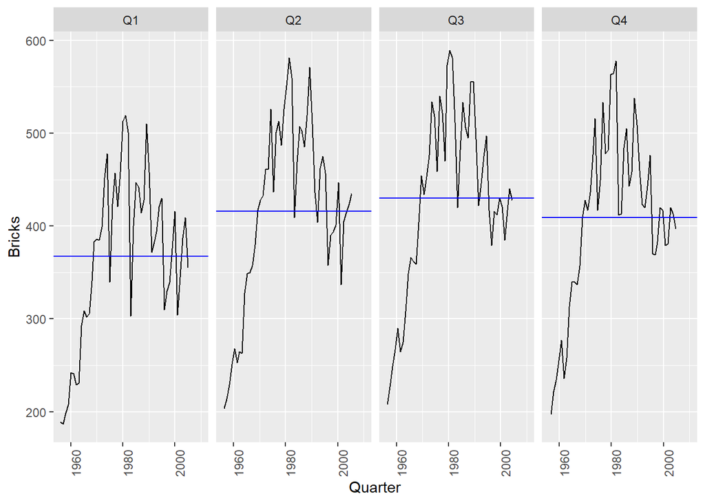

```r
gg_subseries(aus_production, y = Bricks)
```

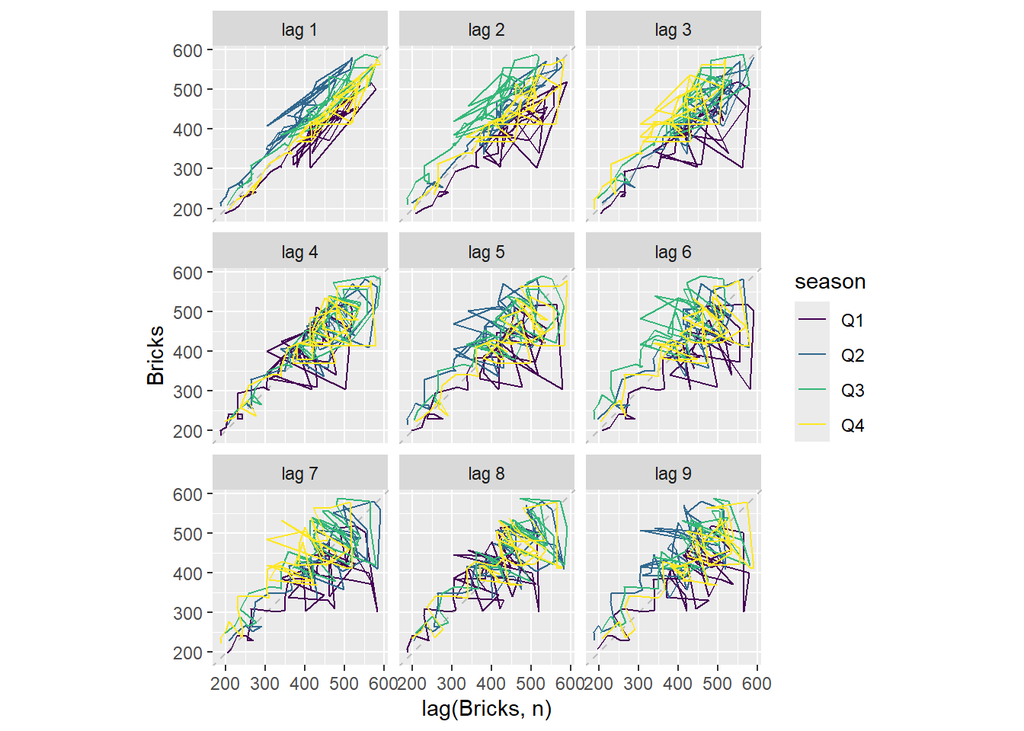

```r
gg_lag(aus_production, y = Bricks)
```

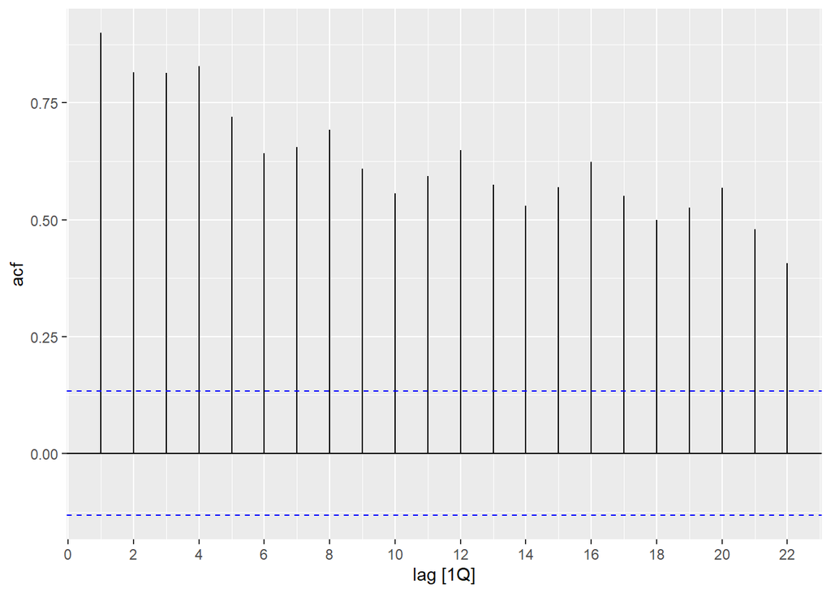

```r
ACF(aus_production, y = Bricks) %>%
  autoplot()
```

As can be seen above, the `Bricks` time series from `aus_production` gives clear signs of seasonality where the number of bricks produced goes up in quarters two and three to drop dramatically towards the beginning of the following year. The series was cyclical every few years and had some especially hard dips around the years 1975, 1983, 1991, and 1996. The over all trend began positive up until around 1983 where things began going south. This could probably be due to consumer demand for bricks decreasing throughout the last few decades.

```r
pelt
```

```
## # A tsibble: 91 x 3 [1Y]
##     Year  Hare  Lynx
##    <dbl> <dbl> <dbl>
##  1  1845 19580 30090
##  2  1846 19600 45150
##  3  1847 19610 49150
##  4  1848 11990 39520
##  5  1849 28040 21230
##  6  1850 58000  8420
##  7  1851 74600  5560
##  8  1852 75090  5080
##  9  1853 88480 10170
## 10  1854 61280 19600
## # ℹ 81 more rows
```

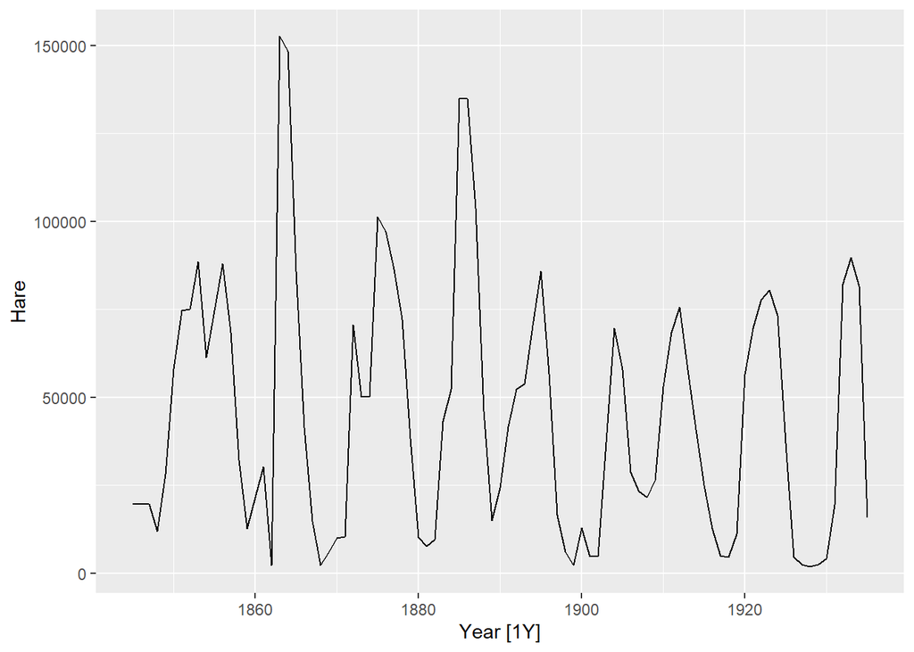

```r
autoplot(pelt, Hare)
```

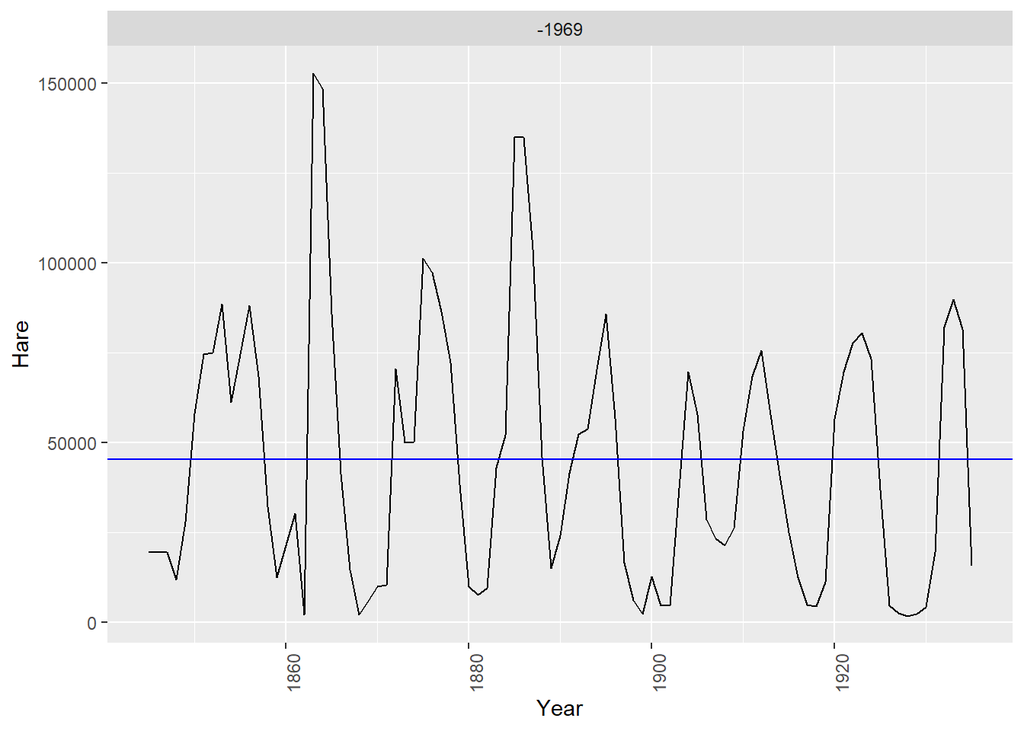

```r
#gg_season(pelt, y = Hare, period = "year") Couldn't get it to work :(
gg_subseries(pelt, y = Hare)
```

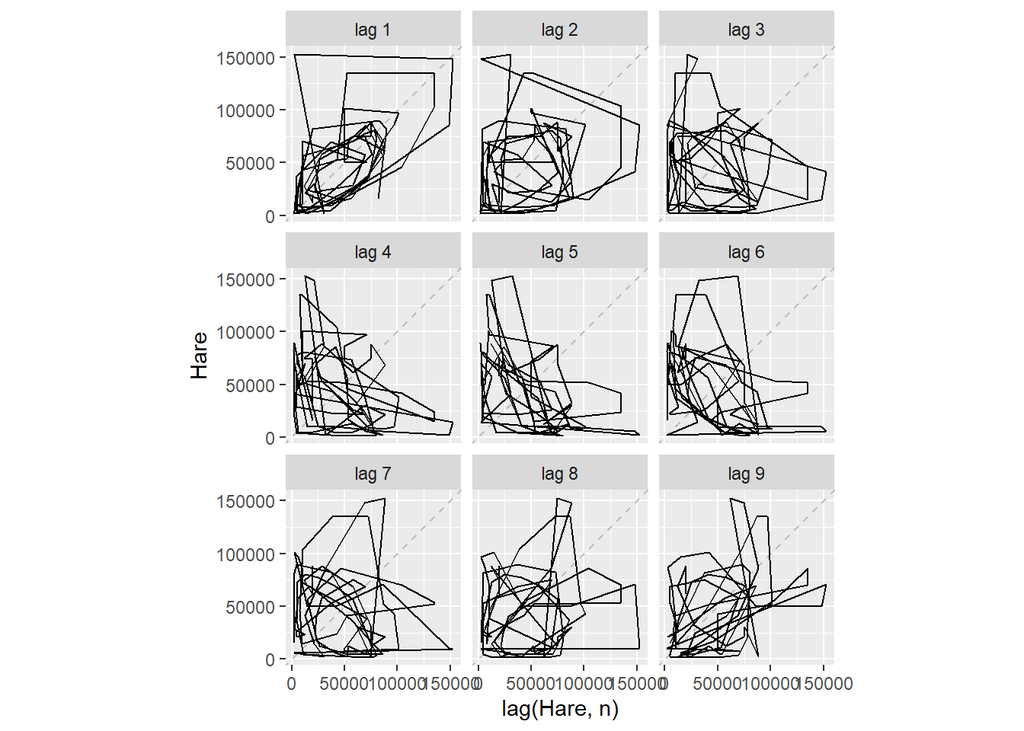

```r
gg_lag(pelt, y = Hare)
```

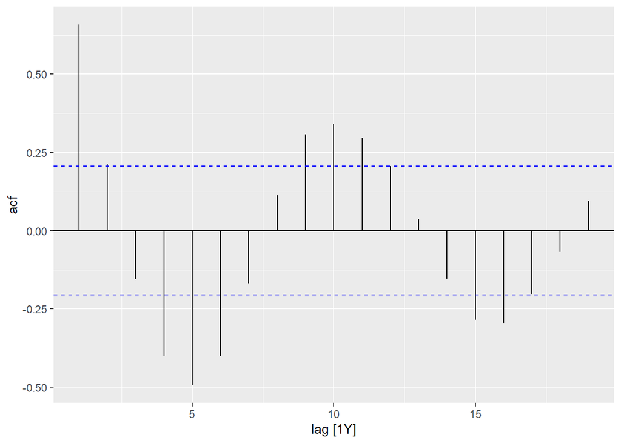

```r
ACF(pelt, y = Hare) %>%
  autoplot()
```

As can be seen above, the `Hare` time series from `pelt` shows very little, f any, signs of seasonality. Seasonality can only be defined within a year, whether it be quarterly, monthly, or weekly. This time series does not show to have yearly patterns but rather a pattern that seems to last around 10 years at a time. This pattern can be better described as cyclical. With regards to trend, there seems to be no indication of one, whether positive or negative. This series is best defined as a pattern of habitual decade long cycles repeating nonstop.

```r
PBS
```

```
## # A tsibble: 67,596 x 9 [1M]
## # Key:       Concession, Type, ATC1, ATC2 [336]
##       Month Concession   Type      ATC1  ATC1_desc ATC2  ATC2_desc Scripts  Cost
##       <mth> <chr>        <chr>     <chr> <chr>     <chr> <chr>       <dbl> <dbl>
##  1 1991 Jul Concessional Co-payme… A     Alimenta… A01   STOMATOL…   18228 67877
##  2 1991 Aug Concessional Co-payme… A     Alimenta… A01   STOMATOL…   15327 57011
##  3 1991 Sep Concessional Co-payme… A     Alimenta… A01   STOMATOL…   14775 55020
##  4 1991 Oct Concessional Co-payme… A     Alimenta… A01   STOMATOL…   15380 57222
##  5 1991 Nov Concessional Co-payme… A     Alimenta… A01   STOMATOL…   14371 52120
##  6 1991 Dec Concessional Co-payme… A     Alimenta… A01   STOMATOL…   15028 54299
##  7 1992 Jan Concessional Co-payme… A     Alimenta… A01   STOMATOL…   11040 39753
##  8 1992 Feb Concessional Co-payme… A     Alimenta… A01   STOMATOL…   15165 54405
##  9 1992 Mar Concessional Co-payme… A     Alimenta… A01   STOMATOL…   16898 61108
## 10 1992 Apr Concessional Co-payme… A     Alimenta… A01   STOMATOL…   18141 65356
## # ℹ 67,586 more rows
```

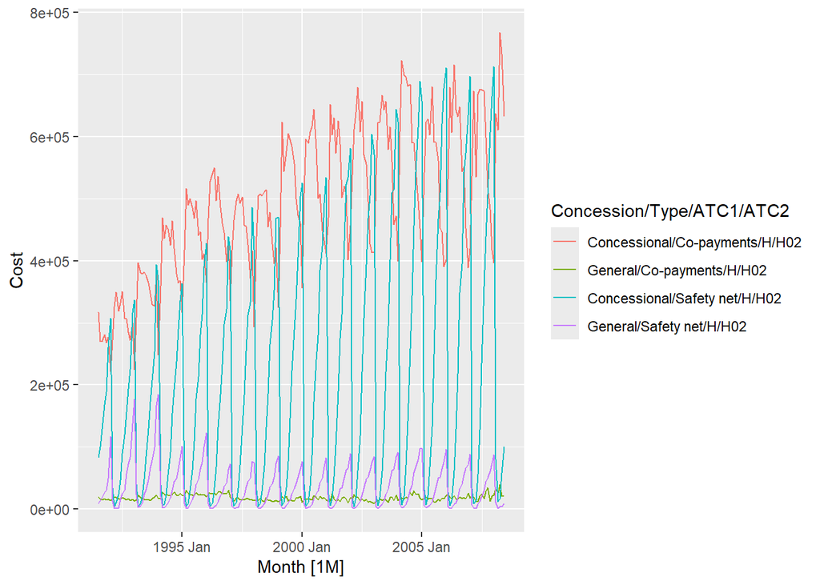

```r
H02 <- PBS %>%
  filter(ATC2 == "H02")
autoplot(H02, Cost)
```

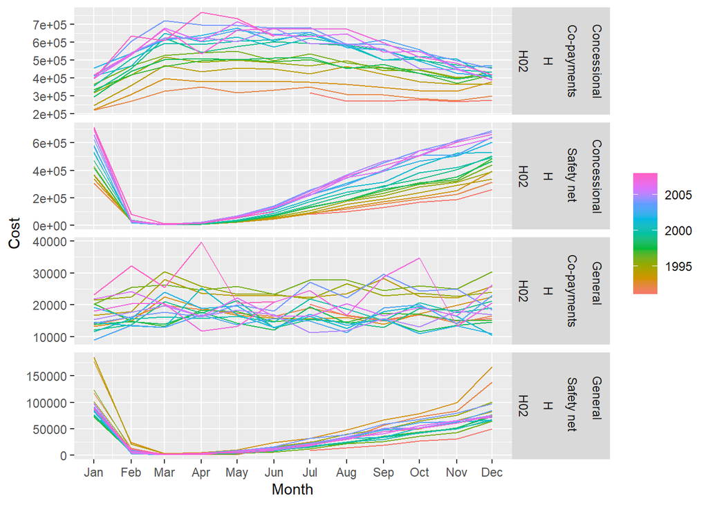

```r
gg_season(H02, y = Cost)
```

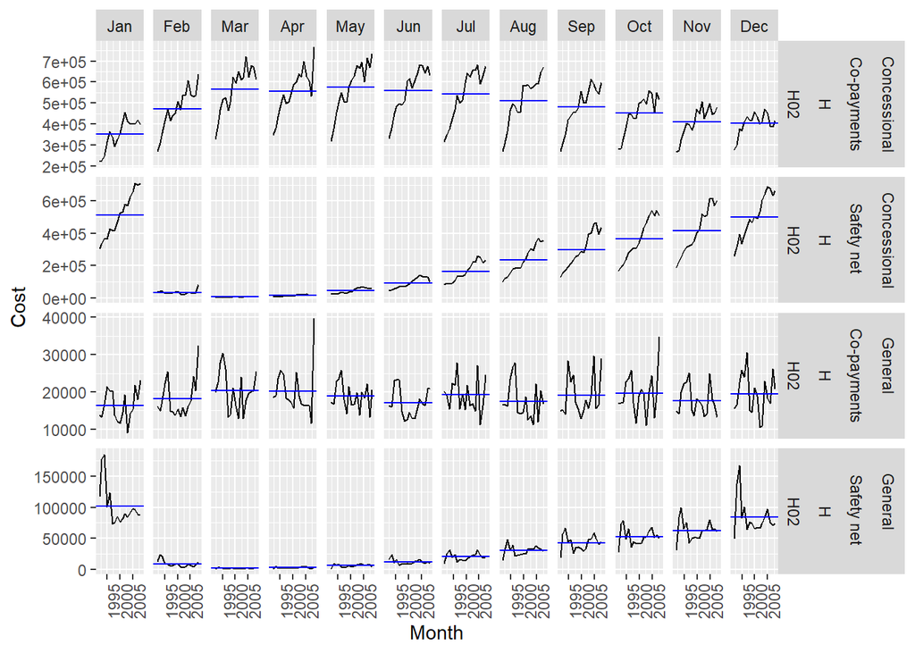

```r
gg_subseries(H02, y = Cost)
```

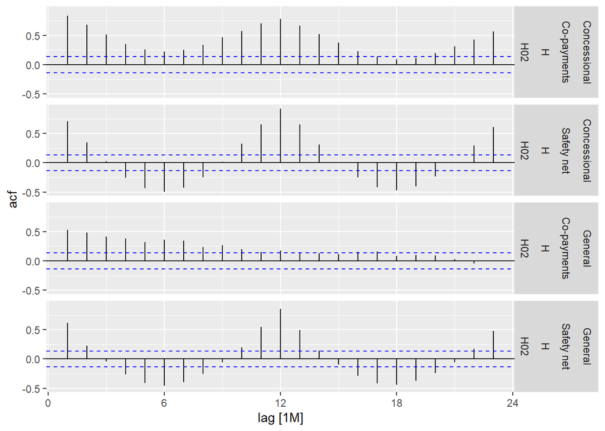

```r
#gg_lag(H02, y = Cost) Couldn't get it to work :(
ACF(H02, y = Cost) %>%
  autoplot()
```

As can be seen above, the “H02” `Cost` time series from `PBS` is seasonal for some `Concession`/`Type` combinations but not for all. Right off the bat we can see in the `gg_season` and `gg_subseries` plots that general/co_payments combination is not seasonal, while the rest are. Concessional/co-payments seems to rise throughout the middle months, concessional/safety net seems to dip during the middle months, and general/safety net seems to rise slightly during the final months of the year. Given the above plots, we can’t say for sure whether there is a cycle since the fluctuations seen can be explained by the seasonality mentioned earlier. There are noticeable trends with concessional/co_payments and concessional/safety net moving in the positive throughout the years while general_co-payments and general/safety net remain about the same.

```r
us_gasoline
```

```
## # A tsibble: 1,355 x 2 [1W]
##        Week Barrels
##      <week>   <dbl>
##  1 1991 W06    6.62
##  2 1991 W07    6.43
##  3 1991 W08    6.58
##  4 1991 W09    7.22
##  5 1991 W10    6.88
##  6 1991 W11    6.95
##  7 1991 W12    7.33
##  8 1991 W13    6.78
##  9 1991 W14    7.50
## 10 1991 W15    6.92
## # ℹ 1,345 more rows
```

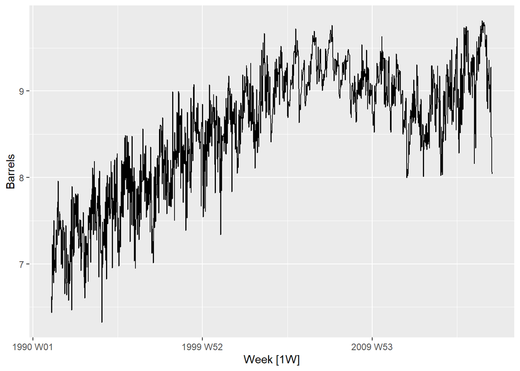

```r
autoplot(us_gasoline, Barrels)
```

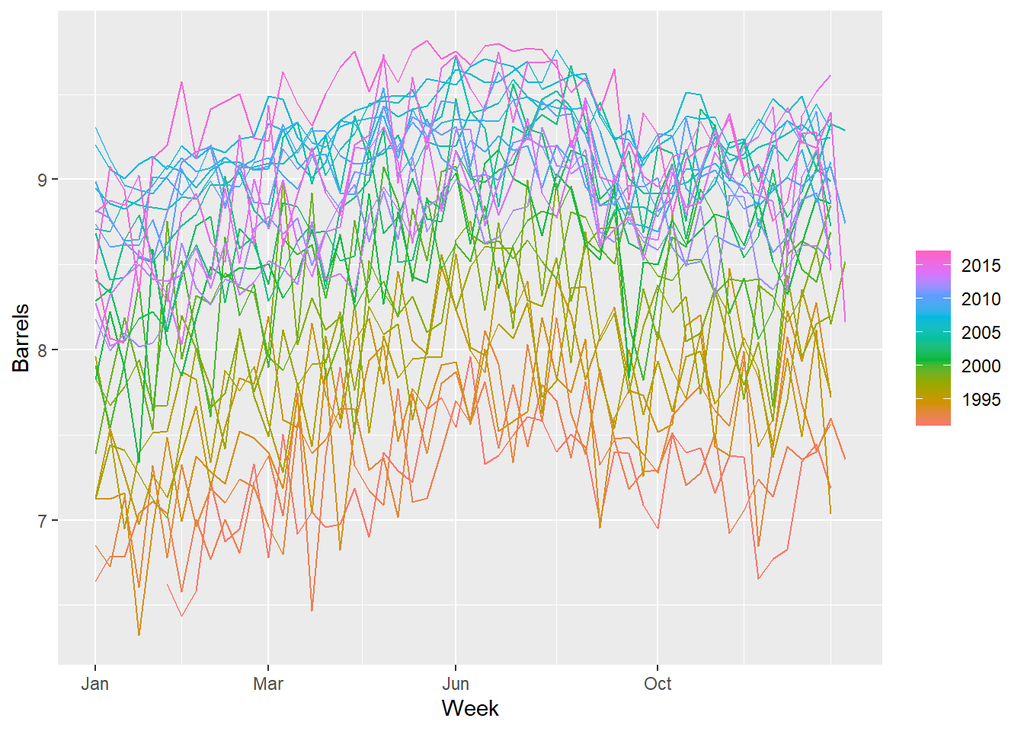

```r
gg_season(us_gasoline, y = Barrels)
```

[figure not shown]

```r
gg_subseries(us_gasoline, y = Barrels)
```

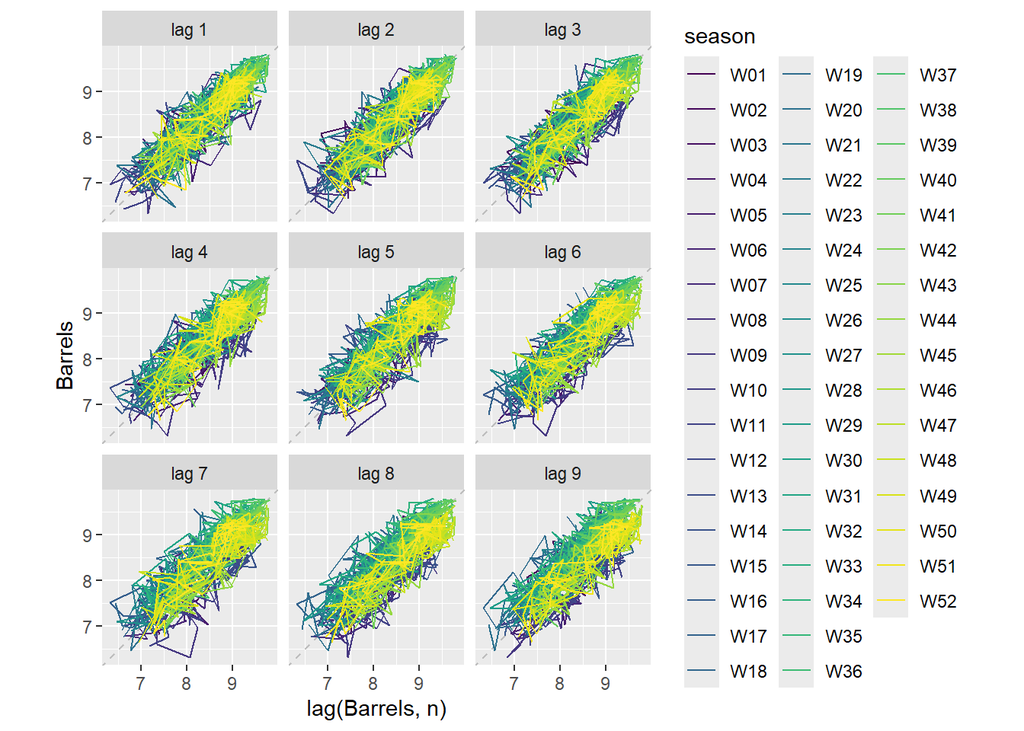

```r
gg_lag(us_gasoline, y = Barrels)
```

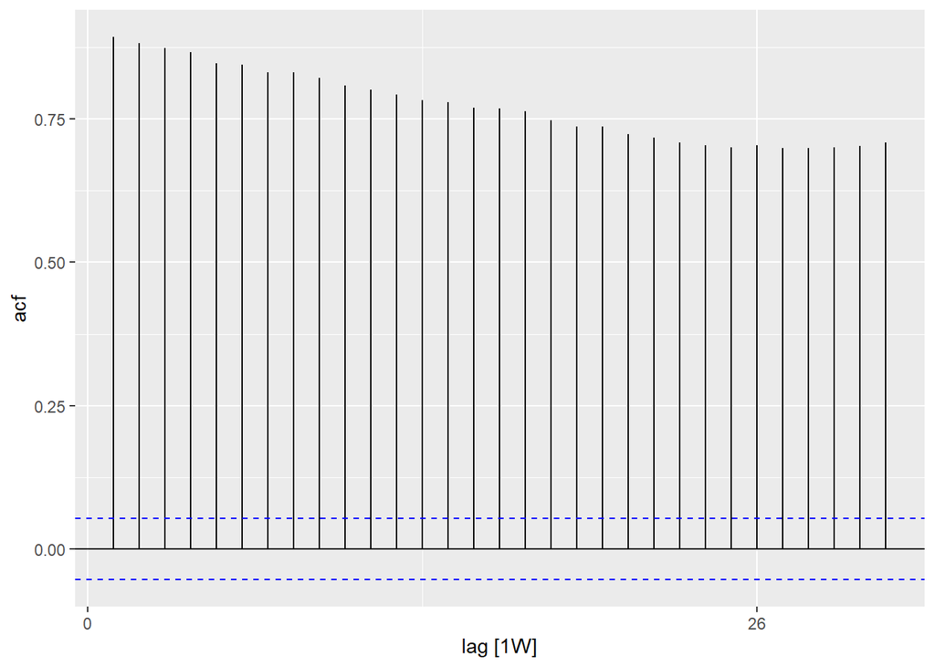

```r
ACF(us_gasoline, y = Barrels) %>%
  autoplot()
```

As can be seen above, the `Barrels` time series from `us_gasoline` does seem to show slight seasonality with the barrels sold between the months of March and October bumping up and going back down shortly after. There don’t seem to be any prominent cycles except for the dip observed around the years 2007 to 2013 which was most likely caused by the [economic recession of 2008](https://www.history.com/topics/21st-century/recession). The overall trend, however, is positive and it seems that US gasoline consumption managed to recover from the downturn.

## Works Cited

History.com Editors. (2019, October 11). Great Recession. HISTORY; A&E Television Networks. https://www.history.com/topics/21st-century/recession